# Merging CIMIS Data

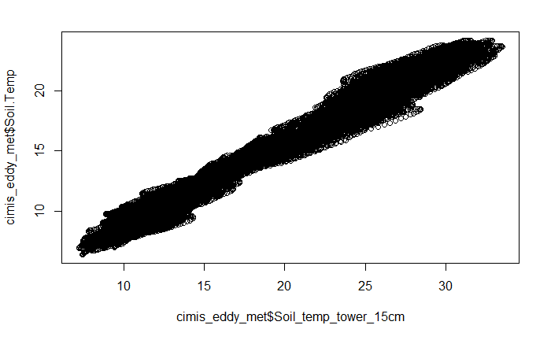

```r
 plot(cimis_eddy_met$Soil_temp_tower_15cm, cimis_eddy_met$Soil.Temp)
```

```r
colnames(cimis_eddy_met)
```

```
  [1] "time.id"                       "filename"                      "date"
  [4] "time"                          "DOY.x"                         "daytime"
  [7] "file_records"                  "used_records"                  "Tau"
 [10] "qc_Tau"                        "H"                             "qc_H"
 [13] "LE"                            "qc_LE"                         "co2_flux"
 [16] "qc_co2_flux"                   "h2o_flux"                      "qc_h2o_flux"
 [19] "H_strg"                        "LE_strg"                       "co2_strg"
 [22] "h2o_strg"                      "co2_v.adv"                     "h2o_v.adv"
 [25] "co2_molar_density"             "co2_mole_fraction"             "co2_mixing_ratio"
 [28] "co2_time_lag"                  "co2_def_timelag"               "h2o_molar_density"
 [31] "h2o_mole_fraction"             "h2o_mixing_ratio"              "h2o_time_lag"
 [34] "h2o_def_timelag"               "sonic_temperature"             "air_temperature"
 [37] "air_pressure"                  "air_density"                   "air_heat_capacity"
 [40] "air_molar_volume"              "ET"                            "water_vapor_density"
 [43] "e"                             "es"                            "specific_humidity"
```

[output cut: 64 more lines]

#combining remaining treatment side thermocouples to get mean soil temp data for remaining depths.

```r
#####0cm_treatment#######
cimis_eddy_met$Soil_temp_tower_0cm <- apply(cimis_eddy_met[,c('TC_Avg.1.', 'TC_Avg.6.' , 'TC_Avg.11.')], 1, function(x) mean(x))

summary(cimis_eddy_met$Soil_temp_tower_0cm)
```

```
   Min. 1st Qu.  Median    Mean 3rd Qu.    Max.    NA's
  2.954  11.510  18.290  19.708  26.513  44.867    7279
```

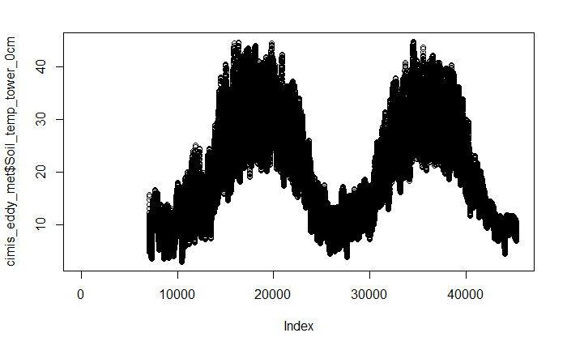

```r
plot(cimis_eddy_met$Soil_temp_tower_0cm)
```

```r
############5cm_treatment####################
cimis_eddy_met$Soil_temp_tower_5cm <- apply(cimis_eddy_met[,c('TC_Avg.2.', 'TC_Avg.7.' , 'TC_Avg.12.')], 1, function(x) mean(x))

summary(cimis_eddy_met$Soil_temp_tower_5cm)
```

```
   Min. 1st Qu.  Median    Mean 3rd Qu.    Max.    NA's
  4.545  11.767  17.800  19.352  26.580  39.423    8164
```

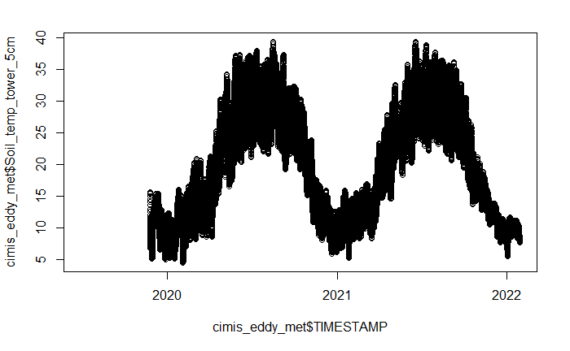

```r
plot( cimis_eddy_met$TIMESTAMP, cimis_eddy_met$Soil_temp_tower_5cm)
```

```r
#############10cm_treatment########################
cimis_eddy_met$Soil_temp_tower_10cm <- apply(cimis_eddy_met[,c('TC_Avg.3.', 'TC_Avg.8.' , 'TC_Avg.13.')], 1, function(x) mean(x))

summary(cimis_eddy_met$Soil_temp_tower_10cm)
```

```
   Min. 1st Qu.  Median    Mean 3rd Qu.    Max.    NA's
  6.132  12.113  17.227  18.704  25.500  35.917   12644
```

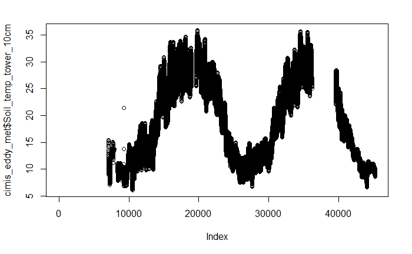

```r
plot(cimis_eddy_met$Soil_temp_tower_10cm)
```

```r
###############30cm_treatment######################
cimis_eddy_met$Soil_temp_tower_30cm <- apply(cimis_eddy_met[,c('TC_Avg.5.', 'TC_Avg.10.' , 'TC_Avg.15.')], 1, function(x) mean(x))

summary(cimis_eddy_met$Soil_temp_tower_30cm)
```

```
   Min. 1st Qu.  Median    Mean 3rd Qu.    Max.    NA's
   9.26   13.08   18.63   19.07   25.46   29.36    7131
```

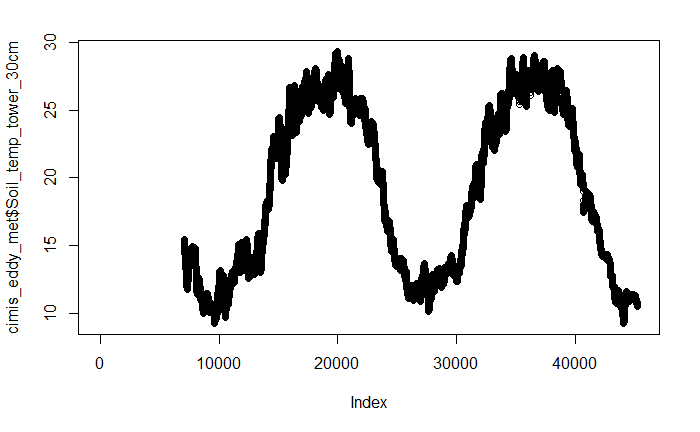

```r
plot(cimis_eddy_met$Soil_temp_tower_30cm)
```

#gap filling the 10cm soil temps with the 15cm soil temps(combo of tower data and cimisdata)

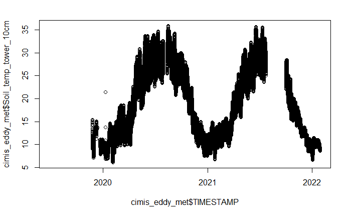

```r
#Soil temp Calculated from tower's thermocouples sensors
plot(cimis_eddy_met$TIMESTAMP, cimis_eddy_met$Soil_temp_tower_10cm)
```

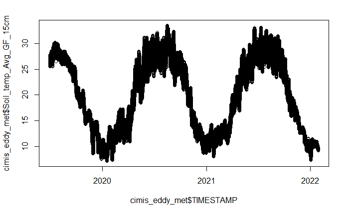

```r
#CIMIS and tower
plot(cimis_eddy_met$TIMESTAMP, cimis_eddy_met$Soil_temp_Avg_GF_15cm)
```

```r
summary(cimis_eddy_met$Soil_temp_Avg_GF_15cm)
```

```
   Min. 1st Qu.  Median    Mean 3rd Qu.    Max.    NA's
  7.214  13.020  20.053  19.893  26.620  33.497       3
```

```r
summary(cimis_eddy_met$Soil_temp_tower_10cm)
```

```
   Min. 1st Qu.  Median    Mean 3rd Qu.    Max.    NA's
  6.132  12.113  17.227  18.704  25.500  35.917   12644
```

```r
 #linear model looking at 10 cm gap fill data and 10cm data
 summary(lm(cimis_eddy_met$Soil_temp_tower_10cm ~ cimis_eddy_met$Soil_temp_Avg_GF_15cm,na.action=na.omit))
```

```
Call:
lm(formula = cimis_eddy_met$Soil_temp_tower_10cm ~ cimis_eddy_met$Soil_temp_Avg_GF_15cm,
    na.action = na.omit)

Residuals:
    Min      1Q  Median      3Q     Max
-1.7329 -0.5182 -0.0522  0.4486 12.7146

Coefficients:
                                       Estimate Std. Error t value Pr(>|t|)
(Intercept)                          -1.0444637  0.0119577  -87.35   <2e-16 ***
cimis_eddy_met$Soil_temp_Avg_GF_15cm  1.0611418  0.0006024 1761.44   <2e-16 ***
---
Signif. codes:  0 ‘***’ 0.001 ‘**’ 0.01 ‘*’ 0.05 ‘.’ 0.1 ‘ ’ 1

Residual standard error: 0.7508 on 32607 degrees of freedom
  (12644 observations deleted due to missingness)
Multiple R-squared:  0.9896,    Adjusted R-squared:  0.9896
F-statistic: 3.103e+06 on 1 and 32607 DF,  p-value: < 2.2e-16
```

```r
 #applying this model to CIMIS data
cimis_eddy_met$Soil_temp_predict_10cm<-cimis_eddy_met$Soil.Temp* 1.0611418  -1.0444637

  summary(cimis_eddy_met$Soil_temp_predict_10cm)
```

```
   Min. 1st Qu.  Median    Mean 3rd Qu.    Max.    NA's
  5.747  10.257  15.509  15.440  20.762  24.635       3
```

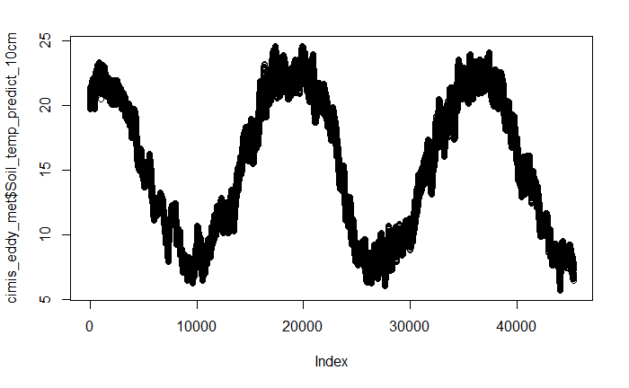

```r
  plot(cimis_eddy_met$Soil_temp_predict_10cm)
```

```r
  summary(cimis_eddy_met$Soil_temp_tower_10cm)
```

```
   Min. 1st Qu.  Median    Mean 3rd Qu.    Max.    NA's
  6.132  12.113  17.227  18.704  25.500  35.917   12644
```

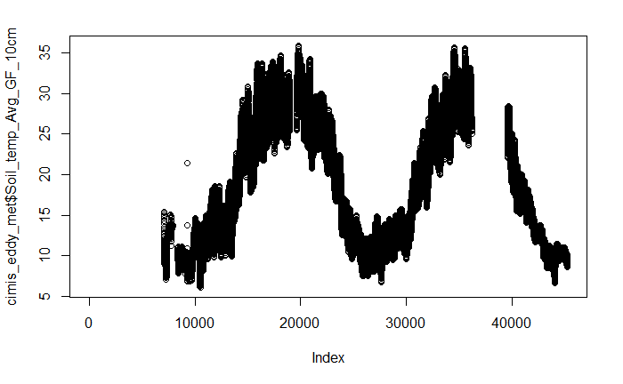

```r
 cimis_eddy_met$Soil_temp_Avg_GF_10cm<-cimis_eddy_met$Soil_temp_tower_10cm

 plot(cimis_eddy_met$Soil_temp_Avg_GF_10cm)
```

```r
 #filling icoming soil temp data with CIMIS templinearly adjusted data
 cimis_eddy_met$Soil_temp_Avg_GF_10cm[is.na(cimis_eddy_met$Soil_temp_Avg_GF_10cm)]<-cimis_eddy_met$Soil_temp_predict_10cm[is.na(cimis_eddy_met$Soil_temp_Avg_GF_10cm)]


 summary(cimis_eddy_met$Soil_temp_predict_10cm)
```

```
   Min. 1st Qu.  Median    Mean 3rd Qu.    Max.    NA's
  5.747  10.257  15.509  15.440  20.762  24.635       3
```

```r
 summary(cimis_eddy_met$Soil_temp_Avg_GF_10cm)
```

```
   Min. 1st Qu.  Median    Mean 3rd Qu.    Max.    NA's
  6.132  12.430  18.703  18.522  23.150  35.917       3
```

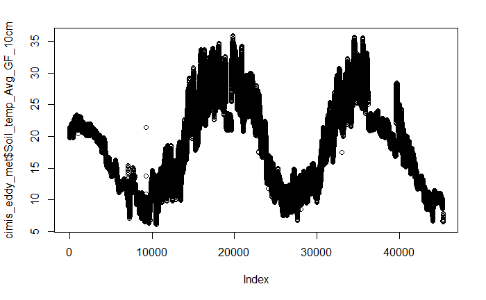

```r
 plot(cimis_eddy_met$Soil_temp_Avg_GF_10cm)
```

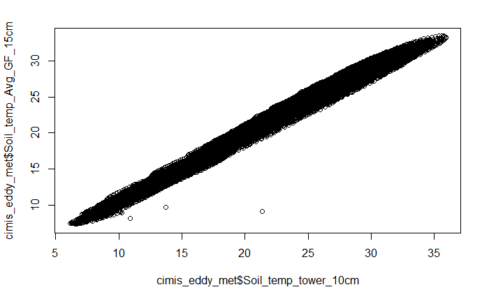

```r
 plot(cimis_eddy_met$Soil_temp_tower_10cm, cimis_eddy_met$Soil_temp_Avg_GF_15cm)
```

[figure not shown]

#renaming control side thermocouples

```r
####0_cm_control###########

cimis_eddy_met$TC_control_0cm<-cimis_eddy_met$TC_Avg.16._control

summary(cimis_eddy_met$TC_control_0cm)
```

```
   Min. 1st Qu.  Median    Mean 3rd Qu.    Max.    NA's
   2.71   11.76   17.48   20.11   26.11   50.00   28105
```

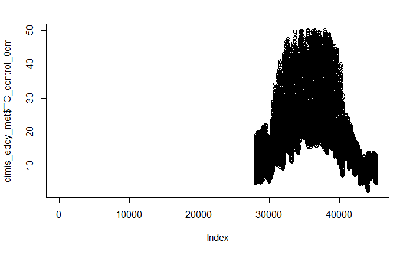

```r
plot(cimis_eddy_met$TC_control_0cm)
```

```r
###########5cm_control#########################
cimis_eddy_met$TC_control_5cm<-cimis_eddy_met$TC_Avg.17._control

summary(cimis_eddy_met$TC_control_5cm)
```

```
   Min. 1st Qu.  Median    Mean 3rd Qu.    Max.    NA's
  4.435  12.337  19.050  19.960  26.310  42.690   28045
```

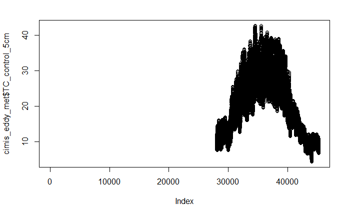

```r
plot(cimis_eddy_met$TC_control_5cm)
```

```r
###########10cm_control#########################
cimis_eddy_met$TC_control_10cm<-cimis_eddy_met$TC_Avg.18._control

summary(cimis_eddy_met$TC_control_10cm)
```

```
   Min. 1st Qu.  Median    Mean 3rd Qu.    Max.    NA's
  5.514  12.627  19.480  19.814  26.240  37.610   28045
```

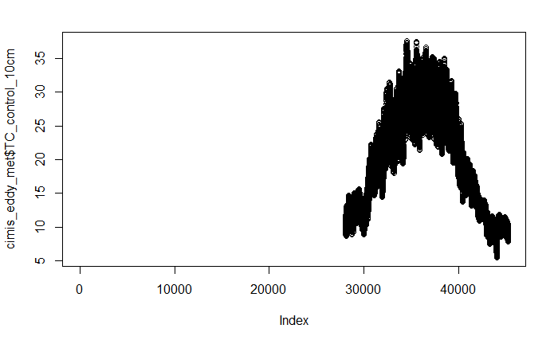

```r
plot(cimis_eddy_met$TC_control_10cm)
```

```r
###########15cm_control#########################
cimis_eddy_met$TC_control_15cm<-cimis_eddy_met$TC_Avg.19._control

summary(cimis_eddy_met$TC_control_15cm)
```

```
   Min. 1st Qu.  Median    Mean 3rd Qu.    Max.    NA's
  6.607  12.820  19.540  19.713  26.130  34.270   28045
```

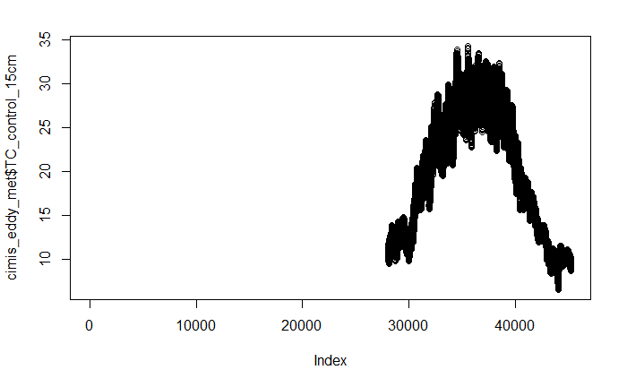

```r
plot(cimis_eddy_met$TC_control_15cm)
```

```r
#############30cm_control##########################
cimis_eddy_met$TC_control_30cm<-cimis_eddy_met$TC_Avg.20._control

summary(cimis_eddy_met$TC_control_30cm)
```

```
   Min. 1st Qu.  Median    Mean 3rd Qu.    Max.    NA's
   8.82   13.31   19.44   19.47   25.46   28.93   28045
```

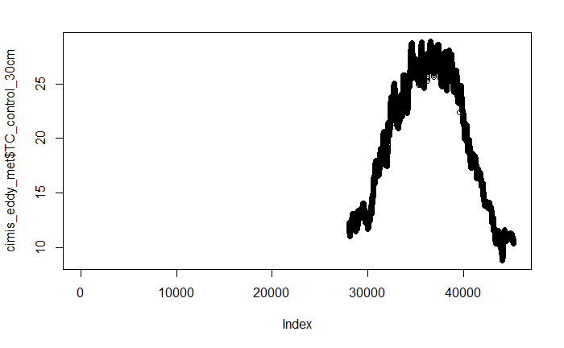

```r
plot(cimis_eddy_met$TC_control_30cm)
```

#linearily expanding control side 0 cm soil temp data from treatment side data

```r
#linear model looking at control 0cm data and treatment side temp data
 summary(lm(cimis_eddy_met$TC_control_0cm ~ cimis_eddy_met$Soil_temp_tower_0cm,na.action=na.omit))
```

```
Call:
lm(formula = cimis_eddy_met$TC_control_0cm ~ cimis_eddy_met$Soil_temp_tower_0cm,
    na.action = na.omit)

Residuals:
   Min     1Q Median     3Q    Max
-7.619 -3.184  0.112  2.091 12.143

Coefficients:
                                    Estimate Std. Error t value Pr(>|t|)
(Intercept)                        -2.930327   0.068223  -42.95   <2e-16 ***
cimis_eddy_met$Soil_temp_tower_0cm  1.122951   0.003052  367.91   <2e-16 ***
---
Signif. codes:  0 ‘***’ 0.001 ‘**’ 0.01 ‘*’ 0.05 ‘.’ 0.1 ‘ ’ 1

Residual standard error: 3.549 on 17142 degrees of freedom
  (28109 observations deleted due to missingness)
Multiple R-squared:  0.8876,    Adjusted R-squared:  0.8876
F-statistic: 1.354e+05 on 1 and 17142 DF,  p-value: < 2.2e-16
```

```r
 #applying this model to treatment data
cimis_eddy_met$Soil_temp_predict_0cm_control<-cimis_eddy_met$Soil_temp_tower_0cm* 1.122951  -2.930327

#checking out the predicted control data via summary and plot
summary(cimis_eddy_met$TC_control_0cm)
```

```
   Min. 1st Qu.  Median    Mean 3rd Qu.    Max.    NA's
   2.71   11.76   17.48   20.11   26.11   50.00   28105
```

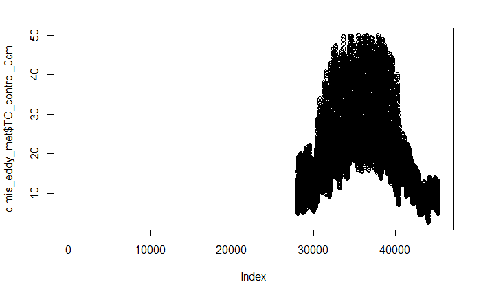

```r
plot(cimis_eddy_met$TC_control_0cm)
```

```r
#checking out the predicted control data via summary and plot
summary(cimis_eddy_met$Soil_temp_predict_0cm_control)
```

```
   Min. 1st Qu.  Median    Mean 3rd Qu.    Max.    NA's
  0.386   9.995  17.608  19.201  26.843  47.453    7279
```

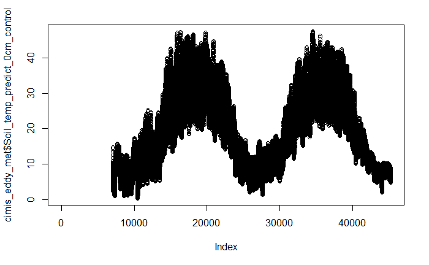

```r
plot(cimis_eddy_met$Soil_temp_predict_0cm_control)
```

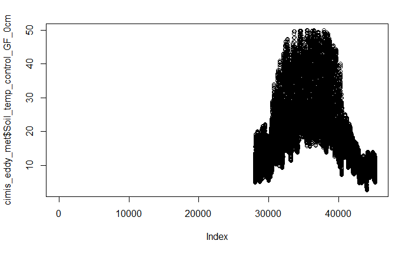

```r
 cimis_eddy_met$Soil_temp_control_GF_0cm<-cimis_eddy_met$TC_control_0cm

 plot(cimis_eddy_met$Soil_temp_control_GF_0cm)
```

```r
 #filling control soil temp data with treatment linearily adjusted data
 cimis_eddy_met$Soil_temp_control_GF_0cm[is.na(cimis_eddy_met$Soil_temp_control_GF_0cm)]<-cimis_eddy_met$Soil_temp_predict_0cm_control[is.na(cimis_eddy_met$Soil_temp_control_GF_0cm)]


 summary(cimis_eddy_met$Soil_temp_predict_0cm_control)
```

```
   Min. 1st Qu.  Median    Mean 3rd Qu.    Max.    NA's
  0.386   9.995  17.608  19.201  26.843  47.453    7279
```

```r
 summary(cimis_eddy_met$Soil_temp_control_GF_0cm)
```

```
   Min. 1st Qu.  Median    Mean 3rd Qu.    Max.    NA's
  0.386  10.380  16.911  19.202  26.110  50.000    7275
```

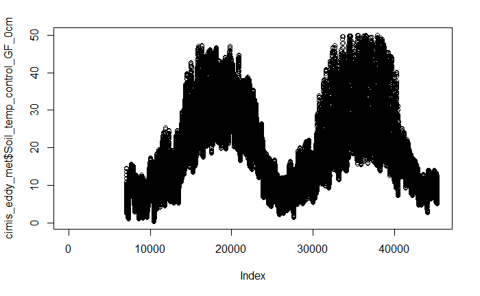

```r
 plot(cimis_eddy_met$Soil_temp_control_GF_0cm)
```

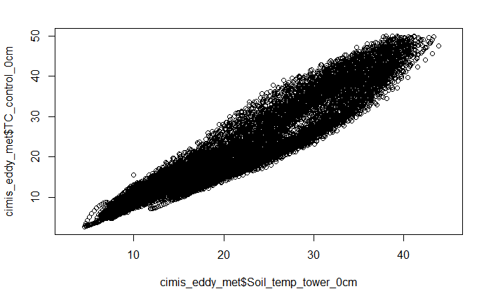

```r
 plot(cimis_eddy_met$Soil_temp_tower_0cm, cimis_eddy_met$TC_control_0cm)
```

#linearily expanding control side 5 cm soil temp data from treatment side data

```r
#linear model looking at control 5cm data and treatment side temp data
 summary(lm(cimis_eddy_met$TC_control_5cm ~ cimis_eddy_met$Soil_temp_tower_5cm,na.action=na.omit))
```

```
Call:
lm(formula = cimis_eddy_met$TC_control_5cm ~ cimis_eddy_met$Soil_temp_tower_5cm,
    na.action = na.omit)

Residuals:
    Min      1Q  Median      3Q     Max
-4.4343 -1.2547  0.0135  0.8658  5.0810

Coefficients:
                                    Estimate Std. Error t value Pr(>|t|)
(Intercept)                        -0.872515   0.033164  -26.31   <2e-16 ***
cimis_eddy_met$Soil_temp_tower_5cm  1.021544   0.001521  671.45   <2e-16 ***
---
Signif. codes:  0 ‘***’ 0.001 ‘**’ 0.01 ‘*’ 0.05 ‘.’ 0.1 ‘ ’ 1

Residual standard error: 1.594 on 16672 degrees of freedom
  (28579 observations deleted due to missingness)
Multiple R-squared:  0.9643,    Adjusted R-squared:  0.9643
F-statistic: 4.508e+05 on 1 and 16672 DF,  p-value: < 2.2e-16
```

```r
 #applying this model to treatment data
cimis_eddy_met$Soil_temp_predict_5cm_control<-cimis_eddy_met$Soil_temp_tower_5cm* 1.021544  -0.872515

#checking out the predicted control data via summary and plot
summary(cimis_eddy_met$TC_control_5cm)
```

```
   Min. 1st Qu.  Median    Mean 3rd Qu.    Max.    NA's
  4.435  12.337  19.050  19.960  26.310  42.690   28045
```

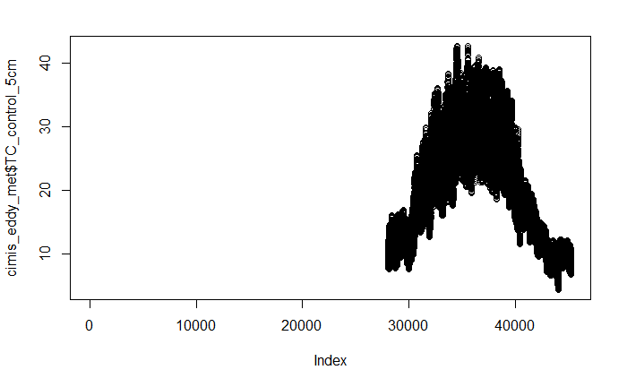

```r
plot(cimis_eddy_met$TC_control_5cm)
```

```r
#checking out the predicted control data via summary and plot
summary(cimis_eddy_met$Soil_temp_predict_5cm_control)
```

```
   Min. 1st Qu.  Median    Mean 3rd Qu.    Max.    NA's
  3.771  11.148  17.311  18.896  26.280  39.400    8164
```

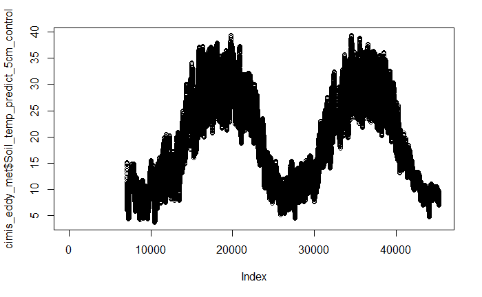

```r
plot(cimis_eddy_met$Soil_temp_predict_5cm_control)
```

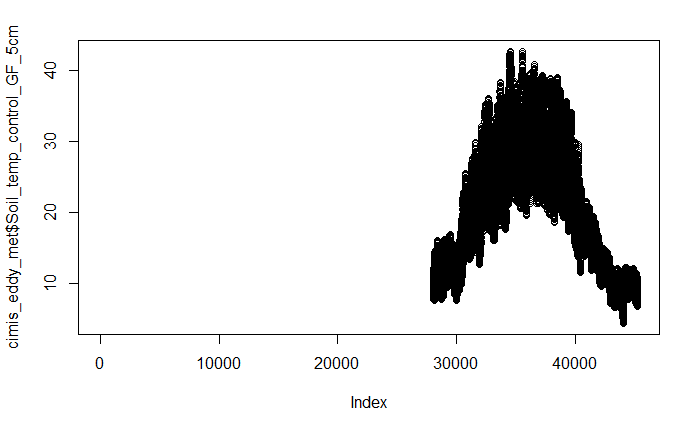

```r
 cimis_eddy_met$Soil_temp_control_GF_5cm<-cimis_eddy_met$TC_control_5cm

 plot(cimis_eddy_met$Soil_temp_control_GF_5cm)
```

```r
 #filling control soil temp data with treatment linearily adjusted data
 cimis_eddy_met$Soil_temp_control_GF_5cm[is.na(cimis_eddy_met$Soil_temp_control_GF_5cm)]<-cimis_eddy_met$Soil_temp_predict_5cm_control[is.na(cimis_eddy_met$Soil_temp_control_GF_5cm)]


 summary(cimis_eddy_met$Soil_temp_predict_5cm_control)
```

```
   Min. 1st Qu.  Median    Mean 3rd Qu.    Max.    NA's
  3.771  11.148  17.311  18.896  26.280  39.400    8164
```

```r
 summary(cimis_eddy_met$Soil_temp_control_GF_5cm)
```

```
   Min. 1st Qu.  Median    Mean 3rd Qu.    Max.    NA's
  3.771  11.352  17.400  18.984  26.000  42.690    7630
```

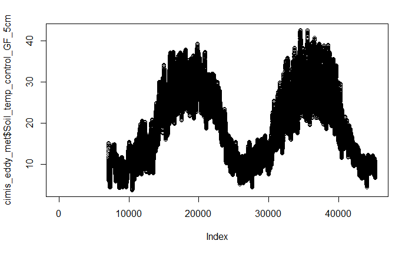

```r
 plot(cimis_eddy_met$Soil_temp_control_GF_5cm)
```

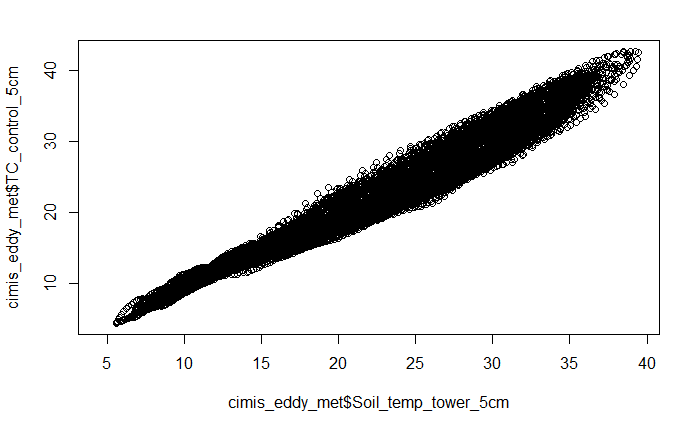

```r
 plot(cimis_eddy_met$Soil_temp_tower_5cm, cimis_eddy_met$TC_control_5cm)
```

#linearily expanding control side 10 cm soil temp data from treatment side data

```r
#linear model looking at control 10cm data and treatment side temp data
 summary(lm(cimis_eddy_met$TC_control_10cm ~ cimis_eddy_met$Soil_temp_tower_10cm,na.action=na.omit))
```

```
Call:
lm(formula = cimis_eddy_met$TC_control_10cm ~ cimis_eddy_met$Soil_temp_tower_10cm,
    na.action = na.omit)

Residuals:
    Min      1Q  Median      3Q     Max
-3.0356 -0.4325  0.0175  0.4368  3.6871

Coefficients:
                                     Estimate Std. Error t value Pr(>|t|)
(Intercept)                         -0.236628   0.021566  -10.97   <2e-16 ***
cimis_eddy_met$Soil_temp_tower_10cm  0.985878   0.001096  899.22   <2e-16 ***
---
Signif. codes:  0 ‘***’ 0.001 ‘**’ 0.01 ‘*’ 0.05 ‘.’ 0.1 ‘ ’ 1

Residual standard error: 0.9055 on 13845 degrees of freedom
  (31406 observations deleted due to missingness)
Multiple R-squared:  0.9832,    Adjusted R-squared:  0.9832
F-statistic: 8.086e+05 on 1 and 13845 DF,  p-value: < 2.2e-16
```

```r
 #applying this model to treatment data
cimis_eddy_met$Soil_temp_predict_10cm_control<-cimis_eddy_met$Soil_temp_tower_10cm* 0.985878  - 0.236628

#checking out the predicted control data via summary and plot
summary(cimis_eddy_met$TC_control_10cm)
```

```
   Min. 1st Qu.  Median    Mean 3rd Qu.    Max.    NA's
  5.514  12.627  19.480  19.814  26.240  37.610   28045
```

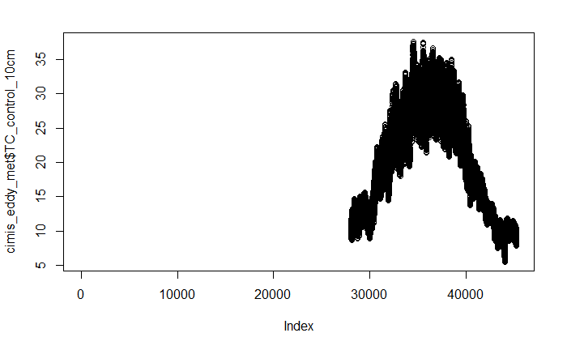

```r
plot(cimis_eddy_met$TC_control_10cm)
```

```r
#checking out the predicted control data via summary and plot
summary(cimis_eddy_met$Soil_temp_predict_10cm_control)
```

```
   Min. 1st Qu.  Median    Mean 3rd Qu.    Max.    NA's
  5.809  11.706  16.747  18.203  24.903  35.173   12644
```

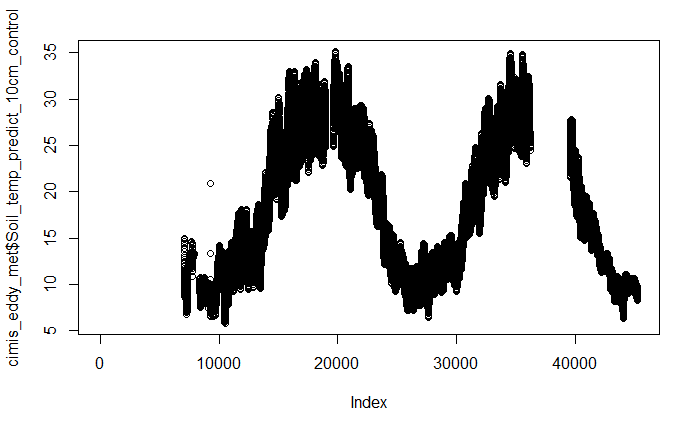

```r
plot(cimis_eddy_met$Soil_temp_predict_10cm_control)
```

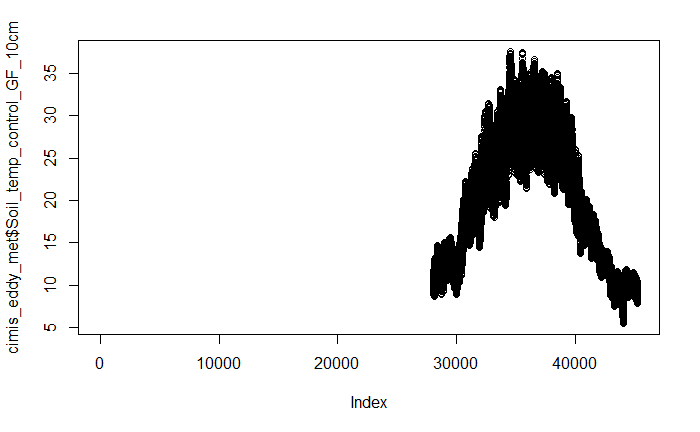

```r
 cimis_eddy_met$Soil_temp_control_GF_10cm<-cimis_eddy_met$TC_control_10cm

 plot(cimis_eddy_met$Soil_temp_control_GF_10cm)
```

```r
 #filling control soil temp data with treatment linearily adjusted data
 cimis_eddy_met$Soil_temp_control_GF_10cm[is.na(cimis_eddy_met$Soil_temp_control_GF_10cm)]<-cimis_eddy_met$Soil_temp_predict_10cm_control[is.na(cimis_eddy_met$Soil_temp_control_GF_10cm)]


 summary(cimis_eddy_met$Soil_temp_predict_10cm_control)
```

```
   Min. 1st Qu.  Median    Mean 3rd Qu.    Max.    NA's
  5.809  11.706  16.747  18.203  24.903  35.173   12644
```

```r
 summary(cimis_eddy_met$Soil_temp_control_GF_10cm)
```

```
   Min. 1st Qu.  Median    Mean 3rd Qu.    Max.    NA's
  5.514  12.032  18.390  19.099  25.781  37.610    9283
```

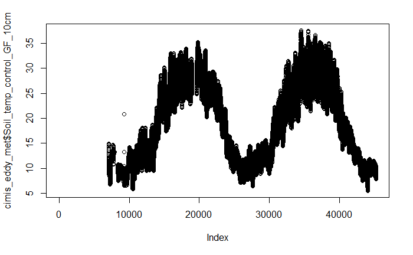

```r
 plot(cimis_eddy_met$Soil_temp_control_GF_10cm)
```

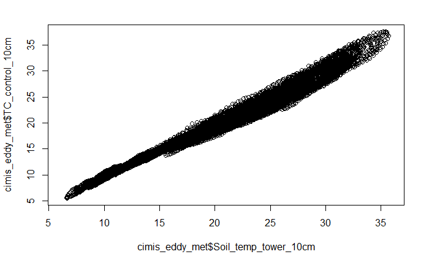

```r
 plot(cimis_eddy_met$Soil_temp_tower_10cm, cimis_eddy_met$TC_control_10cm)
```

#linearily expanding control side 15 cm soil temp data from treatment side data

```r
#linear model looking at control 15cm data and treatment side temp data
 summary(lm(cimis_eddy_met$TC_control_15cm ~ cimis_eddy_met$Soil_temp_Avg_GF_15cm,na.action=na.omit))
```

```
Call:
lm(formula = cimis_eddy_met$TC_control_15cm ~ cimis_eddy_met$Soil_temp_Avg_GF_15cm,
    na.action = na.omit)

Residuals:
     Min       1Q   Median       3Q      Max
-2.31005 -0.31630  0.02618  0.30181  2.03145

Coefficients:
                                       Estimate Std. Error t value Pr(>|t|)
(Intercept)                          -0.3028919  0.0137166  -22.08   <2e-16 ***
cimis_eddy_met$Soil_temp_Avg_GF_15cm  0.9942428  0.0006431 1545.93   <2e-16 ***
---
Signif. codes:  0 ‘***’ 0.001 ‘**’ 0.01 ‘*’ 0.05 ‘.’ 0.1 ‘ ’ 1

Residual standard error: 0.5941 on 17206 degrees of freedom
  (28045 observations deleted due to missingness)
Multiple R-squared:  0.9929,    Adjusted R-squared:  0.9929
F-statistic: 2.39e+06 on 1 and 17206 DF,  p-value: < 2.2e-16
```

```r
 #applying this model to treatment data
cimis_eddy_met$Soil_temp_predict_15cm_control<-cimis_eddy_met$Soil_temp_Avg_GF_15cm* 0.9942428 - 0.3028919

#checking out the predicted control data via summary and plot
summary(cimis_eddy_met$TC_control_15cm)
```

```
   Min. 1st Qu.  Median    Mean 3rd Qu.    Max.    NA's
  6.607  12.820  19.540  19.713  26.130  34.270   28045
```

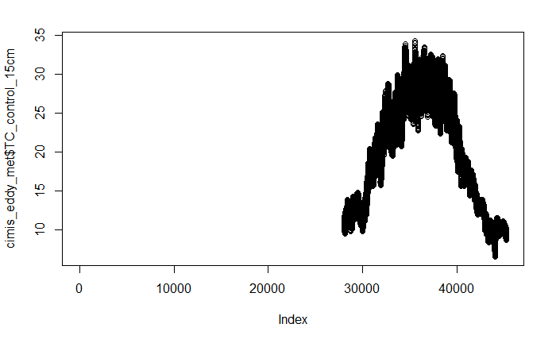

```r
plot(cimis_eddy_met$TC_control_15cm)
```

```r
#checking out the predicted control data via summary and plot
summary(cimis_eddy_met$Soil_temp_predict_15cm_control)
```

```
   Min. 1st Qu.  Median    Mean 3rd Qu.    Max.    NA's
   6.87   12.64   19.63   19.48   26.16   33.00       3
```

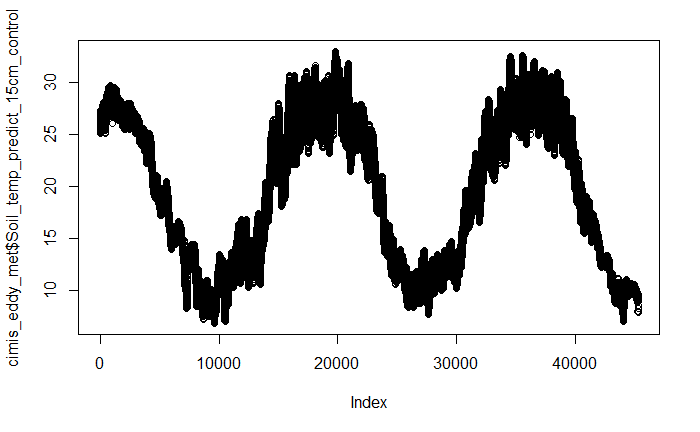

```r
plot(cimis_eddy_met$Soil_temp_predict_15cm_control)
```

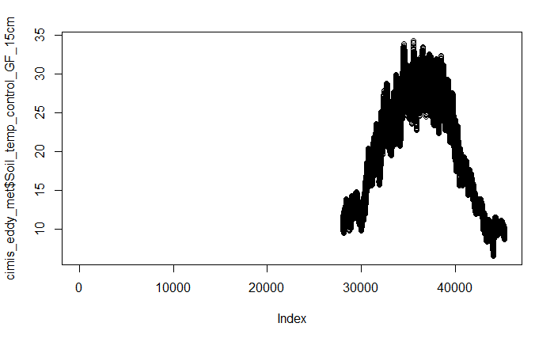

```r
 cimis_eddy_met$Soil_temp_control_GF_15cm<-cimis_eddy_met$TC_control_15cm

 plot(cimis_eddy_met$Soil_temp_control_GF_15cm)
```

```r
 #filling control soil temp data with treatment linearily adjusted data
 cimis_eddy_met$Soil_temp_control_GF_15cm[is.na(cimis_eddy_met$Soil_temp_control_GF_15cm)]<-cimis_eddy_met$Soil_temp_predict_15cm_control[is.na(cimis_eddy_met$Soil_temp_control_GF_15cm)]


 summary(cimis_eddy_met$Soil_temp_predict_15cm_control)
```

```
   Min. 1st Qu.  Median    Mean 3rd Qu.    Max.    NA's
   6.87   12.64   19.63   19.48   26.16   33.00       3
```

```r
 summary(cimis_eddy_met$Soil_temp_control_GF_15cm)
```

```
   Min. 1st Qu.  Median    Mean 3rd Qu.    Max.    NA's
  6.607  12.675  19.566  19.476  26.091  34.270       3
```

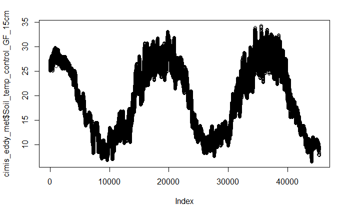

```r
 plot(cimis_eddy_met$Soil_temp_control_GF_15cm)
```

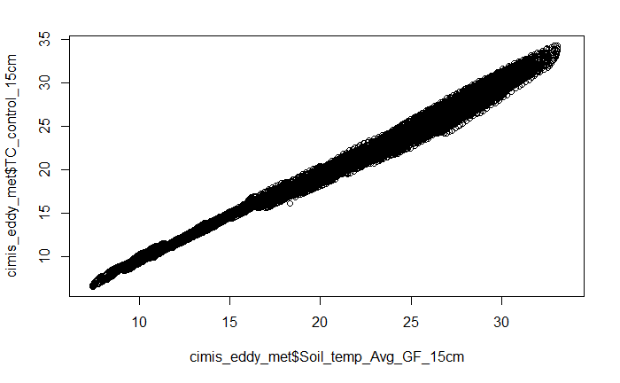

```r
 plot(cimis_eddy_met$Soil_temp_Avg_GF_15cm, cimis_eddy_met$TC_control_15cm)
```

#linearily expanding control side 30 cm soil temp data from treatment side data

```r
#linear model looking at control 30_cm data and treatment side temp data
 summary(lm(cimis_eddy_met$TC_control_30cm ~ cimis_eddy_met$Soil_temp_tower_30cm,na.action=na.omit))
```

```
Call:
lm(formula = cimis_eddy_met$TC_control_30cm ~ cimis_eddy_met$Soil_temp_tower_30cm,
    na.action = na.omit)

Residuals:
     Min       1Q   Median       3Q      Max
-1.51884 -0.11786  0.01556  0.15722  1.52817

Coefficients:
                                      Estimate Std. Error t value Pr(>|t|)
(Intercept)                         -0.2166233  0.0062638  -34.58   <2e-16 ***
cimis_eddy_met$Soil_temp_tower_30cm  0.9916848  0.0003015 3288.67   <2e-16 ***
---
Signif. codes:  0 ‘***’ 0.001 ‘**’ 0.01 ‘*’ 0.05 ‘.’ 0.1 ‘ ’ 1

Residual standard error: 0.2417 on 17206 degrees of freedom
  (28045 observations deleted due to missingness)
Multiple R-squared:  0.9984,    Adjusted R-squared:  0.9984
F-statistic: 1.082e+07 on 1 and 17206 DF,  p-value: < 2.2e-16
```

```r
 #applying this model to treatment data
cimis_eddy_met$Soil_temp_predict_30cm_control<-cimis_eddy_met$Soil_temp_tower_30cm*  0.9916848 -0.2166233

#checking out the predicted control data via summary and plot
summary(cimis_eddy_met$TC_control_30cm)
```

```
   Min. 1st Qu.  Median    Mean 3rd Qu.    Max.    NA's
   8.82   13.31   19.44   19.47   25.46   28.93   28045
```

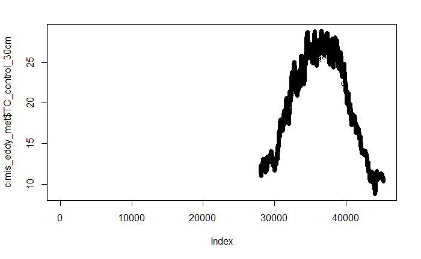

```r
plot(cimis_eddy_met$TC_control_30cm)
```

```r
#checking out the predicted control data via summary and plot
summary(cimis_eddy_met$Soil_temp_predict_30cm_control)
```

```
   Min. 1st Qu.  Median    Mean 3rd Qu.    Max.    NA's
  8.966  12.751  18.258  18.700  25.035  28.903    7131
```

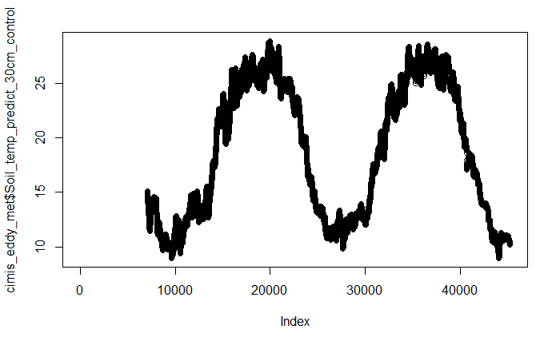

```r
plot(cimis_eddy_met$Soil_temp_predict_30cm_control)
```

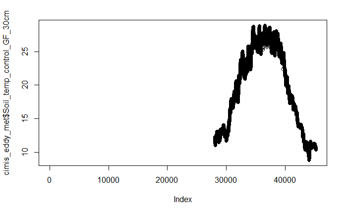

```r
 cimis_eddy_met$Soil_temp_control_GF_30cm<-cimis_eddy_met$TC_control_30cm

 plot(cimis_eddy_met$Soil_temp_control_GF_30cm)
```

```r
 #filling control soil temp data with treatment linearily adjusted data
 cimis_eddy_met$Soil_temp_control_GF_30cm[is.na(cimis_eddy_met$Soil_temp_control_GF_30cm)]<-cimis_eddy_met$Soil_temp_predict_30cm_control[is.na(cimis_eddy_met$Soil_temp_control_GF_30cm)]


 summary(cimis_eddy_met$Soil_temp_predict_30cm_control)
```

```
   Min. 1st Qu.  Median    Mean 3rd Qu.    Max.    NA's
  8.966  12.751  18.258  18.700  25.035  28.903    7131
```

```r
 summary(cimis_eddy_met$Soil_temp_control_GF_30cm)
```

```
   Min. 1st Qu.  Median    Mean 3rd Qu.    Max.    NA's
   8.82   12.78   18.20   18.70   25.02   28.93    7131
```

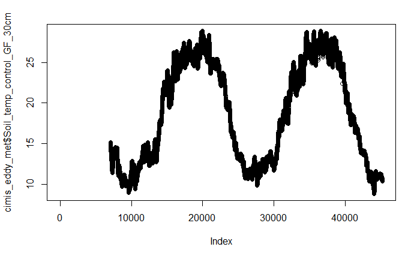

```r
 plot(cimis_eddy_met$Soil_temp_control_GF_30cm)
```

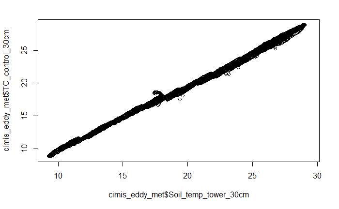

```r
 plot(cimis_eddy_met$Soil_temp_tower_30cm, cimis_eddy_met$TC_control_30cm)
```

#linearily expanding VWC 2

```r
#linear model looking at control VWC and treatment side VWC data
 summary(lm(cimis_eddy_met$VWC_2_Avg_Control ~ cimis_eddy_met$VWC_Avg,na.action=na.omit))
```

```
Call:
lm(formula = cimis_eddy_met$VWC_2_Avg_Control ~ cimis_eddy_met$VWC_Avg,
    na.action = na.omit)

Residuals:
      Min        1Q    Median        3Q       Max
-0.096506 -0.010647 -0.009806  0.011908  0.157284

Coefficients:
                        Estimate Std. Error t value Pr(>|t|)
(Intercept)            0.0092021  0.0002689   34.22   <2e-16 ***
cimis_eddy_met$VWC_Avg 1.0215697  0.0011508  887.66   <2e-16 ***
---
Signif. codes:  0 ‘***’ 0.001 ‘**’ 0.01 ‘*’ 0.05 ‘.’ 0.1 ‘ ’ 1

Residual standard error: 0.02649 on 17205 degrees of freedom
  (28046 observations deleted due to missingness)
Multiple R-squared:  0.9786,    Adjusted R-squared:  0.9786
F-statistic: 7.879e+05 on 1 and 17205 DF,  p-value: < 2.2e-16
```

```r
 #applying this model to treatment data
cimis_eddy_met$VWC_predict_control<-cimis_eddy_met$VWC_Avg*  1.0215697  +  0.0092021

#checking out the predicted control data via summary and plot
summary(cimis_eddy_met$VWC_2_Avg_Control)
```

```
   Min. 1st Qu.  Median    Mean 3rd Qu.    Max.    NA's
  0.012   0.029   0.083   0.167   0.335   0.553   28046
```

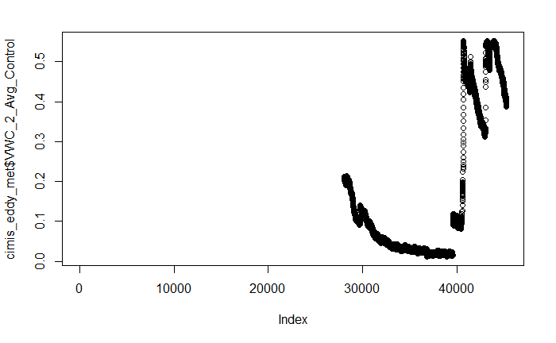

```r
plot(cimis_eddy_met$VWC_2_Avg_Control)
```

```r
#checking out the predicted control data via summary and plot
summary(cimis_eddy_met$VWC_predict_control)
```

```
   Min. 1st Qu.  Median    Mean 3rd Qu.    Max.    NA's
 0.0092  0.0092  0.0378  0.1353  0.2288  0.6313    1750
```

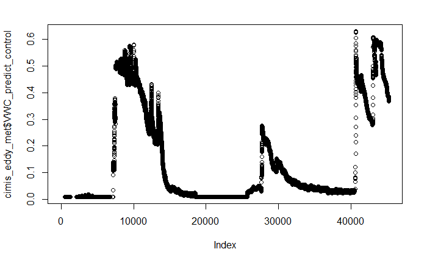

```r
plot(cimis_eddy_met$VWC_predict_control)
```

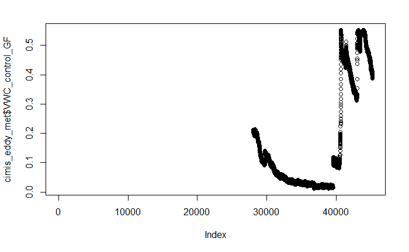

```r
 cimis_eddy_met$VWC_control_GF<-cimis_eddy_met$VWC_2_Avg_Control

 plot(cimis_eddy_met$VWC_control_GF)
```

```r
 #filling control soil temp data with treatment linearily adjusted data
 cimis_eddy_met$VWC_control_GF[is.na(cimis_eddy_met$VWC_control_GF)]<-cimis_eddy_met$VWC_predict_control[is.na(cimis_eddy_met$VWC_control_GF)]


 summary(cimis_eddy_met$VWC_predict_control)
```

```
   Min. 1st Qu.  Median    Mean 3rd Qu.    Max.    NA's
 0.0092  0.0092  0.0378  0.1353  0.2288  0.6313    1750
```

```r
 summary(cimis_eddy_met$VWC_control_GF)
```

```
   Min. 1st Qu.  Median    Mean 3rd Qu.    Max.    NA's
 0.0092  0.0092  0.0340  0.1353  0.2288  0.5803    1750
```

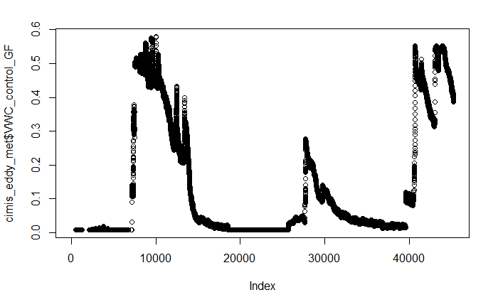

```r
 plot(cimis_eddy_met$VWC_control_GF)
```

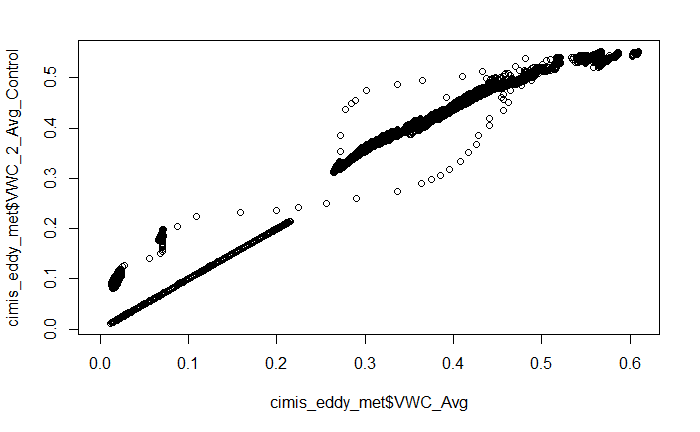

```r
 plot(cimis_eddy_met$VWC_Avg, cimis_eddy_met$VWC_2_Avg_Control)
```

#writing CSV of combined file gap filled file.

```r
write.csv(cimis_eddy_met,
          paste(path.out,Sys.Date(),"_eddy_met_cimis_gap_filled.csv",sep=""),
          quote = T,
          row.names = F)
```

#Creating CSV of data needed for Reddy Proc gap filling

```r
data.reddy_proc<-data.frame(
                    TIMESTAMP = cimis_eddy_met$TIMESTAMP,
                    H= cimis_eddy_met$H,  ## H
                    LE=cimis_eddy_met$LE,    ## LE
                    h2o_flux = cimis_eddy_met$h2o_flux, #h20flux
                    NEE=cimis_eddy_met$co2_flux ,  ## c02 flux\
                    rH = cimis_eddy_met$RH_Avg_GF, #gapfilled relative humidity
                    Ustar = cimis_eddy_met$u.,   #ustar
                    Tsoil = cimis_eddy_met$Soil_temp_Avg_GF_15cm, #gapfilled soil temperature
                    Tair = cimis_eddy_met$AirT_Avg_GF, #gapfilled air temperature
                    Rg=cimis_eddy_met$Rg_Avg_GF  ## incoming solar radiation)

)



head(data.reddy_proc, 100)
```

|  | TIMESTAMP | H | LE | h2o_flux | NEE | rH | Ustar | Tsoil | Tair | Rg |
| --- | --- | --- | --- | --- | --- | --- | --- | --- | --- | --- |
| 1 | 2019-07-01 00:00:00 | -36.96360 | 13.312200 | 0.300071 | 2.009250 | 54.34 | 0.366389 | NA | 16.69873 | NA |
| 2 | 2019-07-01 00:30:00 | -67.19030 | 32.609200 | 0.734689 | 3.704330 | 58.18 | 0.430730 | NA | 16.21755 | NA |
| 3 | 2019-07-01 01:00:00 | -31.69040 | 3.270480 | 0.073600 | 1.526470 | 61.35 | 0.319365 | 27.18132 | 15.42290 | 0.000000 |
| 4 | 2019-07-01 01:30:00 | -40.36350 | 11.788600 | 0.265454 | 1.424570 | 59.72 | 0.310421 | 27.11211 | 15.67635 | 0.000000 |
| 5 | 2019-07-01 02:00:00 | -25.27460 | NA | NA | 1.541480 | 69.99 | 0.343470 | 27.04291 | 14.56917 | 0.000000 |
| 6 | 2019-07-01 02:30:00 | -35.02110 | 5.267570 | 0.118459 | 1.474030 | 71.19 | 0.288058 | 26.90449 | 14.38146 | 0.000000 |
| 7 | 2019-07-01 03:00:00 | -33.30760 | 1.808150 | 0.040700 | 1.407190 | 73.63 | 0.309594 | 26.76607 | 14.21090 | 0.000000 |
| 8 | 2019-07-01 03:30:00 | -32.26780 | -0.455241 | -0.010200 | 1.294180 | 75.15 | 0.280522 | 26.69686 | 13.89361 | 0.000000 |
| 9 | 2019-07-01 04:00:00 | -22.57250 | 3.243090 | 0.072900 | 1.015990 | 72.23 | 0.231343 | 26.62765 | 13.94316 | 0.000000 |
| 10 | 2019-07-01 04:30:00 | -30.66550 | 2.339350 | 0.052600 | 1.212630 | 73.79 | 0.255151 | 26.48923 | 13.73830 | 1.312056 |

[output cut: 90 more lines]

```r
summary(data.reddy_proc)
```

```
   TIMESTAMP                         H                  LE             h2o_flux            NEE
 Min.   :2019-07-01 00:00:00   Min.   :-450.817   Min.   :-62.802   Min.   :-46.543   Min.   :-56.336
 1st Qu.:2020-02-21 14:37:30   1st Qu.: -19.464   1st Qu.: -0.022   1st Qu.: -0.004   1st Qu.: -2.556
 Median :2020-10-14 05:15:00   Median :  -2.384   Median : 11.656   Median :  0.270   Median :  0.273
 Mean   :2020-10-14 05:15:00   Mean   :  43.366   Mean   : 27.729   Mean   :  0.626   Mean   : -0.419
 3rd Qu.:2021-06-06 19:52:30   3rd Qu.:  88.814   3rd Qu.: 43.355   3rd Qu.:  0.998   3rd Qu.:  1.674
 Max.   :2022-01-28 10:30:00   Max.   :1009.310   Max.   :494.770   Max.   : 32.873   Max.   : 31.079
 NA's   :15                    NA's   :8376       NA's   :14405     NA's   :10425     NA's   :12973
       rH              Ustar           Tsoil             Tair              Rg
 Min.   :  6.113   Min.   :0.007   Min.   : 7.214   Min.   :-1.136   Min.   :  0.00
 1st Qu.: 39.438   1st Qu.:0.126   1st Qu.:13.020   1st Qu.:10.750   1st Qu.:  0.00
 Median : 60.500   Median :0.214   Median :20.053   Median :14.970   Median :  7.44
 Mean   : 58.689   Mean   :0.233   Mean   :19.893   Mean   :16.097   Mean   :192.68
 3rd Qu.: 79.010   3rd Qu.:0.314   3rd Qu.:26.620   3rd Qu.:20.590   3rd Qu.:368.09
 Max.   :100.000   Max.   :1.260   Max.   :33.497   Max.   :42.350   Max.   :995.25
 NA's   :1         NA's   :3433    NA's   :3        NA's   :1        NA's   :3
```

```r
write.csv(data.reddy_proc,
          paste(path.out,Sys.Date(),"_reddy_proc.csv",sep=""),
          quote = T,
          row.names = F)

# fWriteDataframeToFile(data.reddy_proc,
#                       paste(path.out,Sys.Date(),"_reddy_proc.txt",sep="")
#          )
```